# Introduction to mlr3

# Intro

**mlr3** is a machine learning framework for R. Together with other packages from the same developers, mostly following the naming scheme "mlr3___", it offers functionality around developing, tuning, and evaluating machine learning workflows.

We will walk through this tutorial interactively. The text is kept short to be followed in real time. There are links to the Appendix for further information that you can read in your spare time.

# Prerequisites

Ensure all packages used in this tutorial are installed. This includes packages from the `mlr3` family, as well as other tools for data handling, cleaning and visualisation which we are going to use. Appendix for more info about packages

```r
# install from CRAN
packages_cran = c("remotes", "data.table", "ggplot2", "skimr", "DataExplorer",
  "precrec", "farff", "curl", "visNetwork", "kknn", "MASS", "ranger",
  "xgboost", "e1071", "future", "future.apply")

# install things from GitHub that are not yet on CRAN
packages_gith = "mlr-org/mlr3viz"

to_install = setdiff(packages_cran, installed.packages()[,"Package"])
if (length(to_install)) install.packages(to_install)
install.packages(c("mlr3", "mlr3misc", "paradox", "mlr3filters", "mlr3learners",
  "mlr3pipelines", "mlr3tuning"))
lapply(packages_gith, remotes::install_github)
```

Load the packages we are going to use:

```r
library("data.table")
library("mlr3")
library("mlr3learners")
library("ggplot2")
theme_set(theme_light())
```

# Machine Learning Use Case: German Credit Data

- The German credit data is a research data set of the University of Hamburg from 1994 donated by Prof. Hans Hoffman.
- Description (and manual download) can be found at the [UCI repository](https://archive.ics.uci.edu/ml/datasets/Statlog+%28German+Credit+Data%29).
- Goal is to classify people by their credit risk (**good** or **bad**) using 20 features:
  - `checking_status: status/balance of checking account at this bank`
  - `duration: duration of the credit in months`
  - `credit_history: past credit history of applicant at this bank`
  - `purpose: reason customer is applying for a loan`
  - `credit_amount: amount asked by applicant`
  - `savings_status: savings accounts/bonds at this bank`
  - `employment: present employment since`
  - `installment_commitment: installment rate in percentage of disposable income`
  - `personal_status: combination of sex and personal status of applicant`
  - `other_parties: other debtors/guarantors present?`
  - `residence_since: present residence since`
  - `property_magnitude: properties that applicant has`
  - `age: age in years`
  - `other_payment_plans: other installment plans the applicant is paying`
  - `housing: type of apartment: rented, owned, for free / no payment`
  - `existing_credits: number of existing credits at this bank`
  - `job: current job information`
  - `num_dependents: number of people being liable to provide maintenance`
  - `own_telephone: is there any telephone registered for this customer?`
  - `foreign_worker: is applicant foreign worker?`

## Importing the Data

We load the dataset from disk. The dataset can also be found on OpenML under https://www.openml.org/d/31

```r
credit = readRDS("credit.rds")
```

## Exploring the Data

- We have a look at the data set before we start modeling.
- The `str()` and `summary()` functions gives an overview of features and their type.
- The `skimr` package gives more readable summaries.
- The `DataExplorer` package lets us visualize categorical (`plot_bar()`) and numeric (`plot_histogram()` and `plot_boxplot()`) data, as well as data relationships.
- Basic things to watch out for:
  - Skewed distributions
  - Missing values
  - Empty / rare factor variables

```r
skimr::skim(credit)
```

Data summary

| Name | credit |
| --- | --- |
| Number of rows | 1000 |
| Number of columns | 21 |
| _______________________ |  |
| Column type frequency: |  |
| factor | 14 |
| numeric | 7 |
| ________________________ |  |
| Group variables | None |

**Variable type: factor**

| skim_variable | n_missing | complete_rate | ordered | n_unique | top_counts |
| --- | --- | --- | --- | --- | --- |
| checking_status | 0 | 1 | FALSE | 4 | no : 394, <0: 274, 0<=: 269, >=2: 63 |
| credit_history | 0 | 1 | FALSE | 5 | exi: 530, cri: 293, del: 88, all: 49 |
| purpose | 0 | 1 | FALSE | 10 | rad: 280, new: 234, fur: 181, use: 103 |
| savings_status | 0 | 1 | FALSE | 5 | <10: 603, no : 183, 100: 103, 500: 63 |
| employment | 0 | 1 | FALSE | 5 | 1<=: 339, >=7: 253, 4<=: 174, <1: 172 |
| personal_status | 0 | 1 | FALSE | 4 | mal: 548, fem: 310, mal: 92, mal: 50 |
| other_parties | 0 | 1 | FALSE | 3 | non: 907, gua: 52, co : 41 |
| property_magnitude | 0 | 1 | FALSE | 4 | car: 332, rea: 282, lif: 232, no : 154 |
| other_payment_plans | 0 | 1 | FALSE | 3 | non: 814, ban: 139, sto: 47 |
| housing | 0 | 1 | FALSE | 3 | own: 713, ren: 179, for: 108 |
| job | 0 | 1 | FALSE | 4 | ski: 630, uns: 200, hig: 148, une: 22 |
| own_telephone | 0 | 1 | FALSE | 2 | non: 596, yes: 404 |
| foreign_worker | 0 | 1 | FALSE | 2 | yes: 963, no: 37 |
| class | 0 | 1 | FALSE | 2 | goo: 700, bad: 300 |

**Variable type: numeric**

| skim_variable | n_missing | complete_rate | mean | sd | p0 | p25 | p50 | p75 | p100 | hist |
| --- | --- | --- | --- | --- | --- | --- | --- | --- | --- | --- |
| duration | 0 | 1 | 20.90 | 12.06 | 4 | 12.0 | 18.0 | 24.00 | 72 | ▇▇▂▁▁ |
| credit_amount | 0 | 1 | 3271.26 | 2822.74 | 250 | 1365.5 | 2319.5 | 3972.25 | 18424 | ▇▂▁▁▁ |
| installment_commitment | 0 | 1 | 2.97 | 1.12 | 1 | 2.0 | 3.0 | 4.00 | 4 | ▂▃▁▂▇ |
| residence_since | 0 | 1 | 2.85 | 1.10 | 1 | 2.0 | 3.0 | 4.00 | 4 | ▂▆▁▃▇ |
| age | 0 | 1 | 35.55 | 11.38 | 19 | 27.0 | 33.0 | 42.00 | 75 | ▇▆▃▁▁ |
| existing_credits | 0 | 1 | 1.41 | 0.58 | 1 | 1.0 | 1.0 | 2.00 | 4 | ▇▅▁▁▁ |
| num_dependents | 0 | 1 | 1.16 | 0.36 | 1 | 1.0 | 1.0 | 1.00 | 2 | ▇▁▁▁▂ |

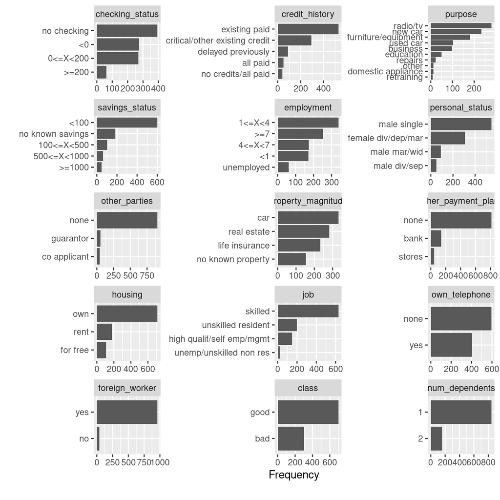

```r
DataExplorer::plot_bar(credit, nrow = 5, ncol = 3)
```

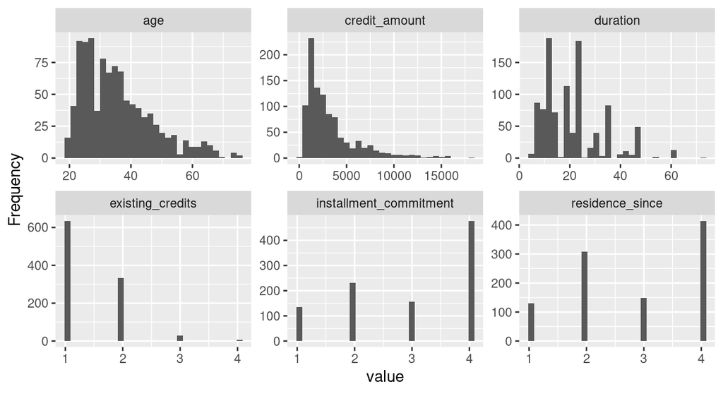

```r
DataExplorer::plot_histogram(credit, nrow = 2, ncol = 3)
```

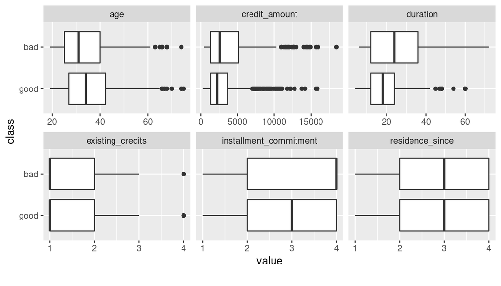

```r
DataExplorer::plot_boxplot(credit, by = "class", nrow = 2, ncol = 3)
```

# Modeling

Considering how we are going to tackle the problem relates closely to what `mlr3` entities we will use.

- What is the problem we are trying to solve?
  - i.e. what **Task** do we use?
  - Binary classification.
  - $\Rightarrow$ We use `TaskClassif`.
- What are appropriate learning algorithms?
  - i.e. what **Learner** do we use?
  - Logistic regression, CART, Random Forest
  - $\Rightarrow$ `lrn("classif.log_reg")`, `lrn("classif.rpart")`, `lrn("classif.ranger")`
- How do we evaluate “good” performance? $\Rightarrow$ Depends on many things! Cost of false positive vs. false negative, legal requirements, …
  - i.e. what **Measure** do we use?
  - We start with misclassification error (simle!) and will also consider AUC.
  - $\Rightarrow$ `msr("classif.ce")`, `msr("classif.auc")`

## Task Definition

With `TaskClassif$new()`, we can initialize a classification task. We need to specify a name for the task, the data we want to use and name of the target variable (here `"class"`):

```r
task = TaskClassif$new("GermanCredit", credit, "class")
```

## Learner Definition

You need to install and load the `mlr3learners` package to get access to a wide range of learners. All available `Learner`s can be obtained by:

```r
mlr_learners
```

```
#> <DictionaryLearner> with 21 stored values
#> Keys: classif.debug, classif.featureless, classif.glmnet, classif.kknn,
#>   classif.lda, classif.log_reg, classif.naive_bayes, classif.qda,
#>   classif.ranger, classif.rpart, classif.svm, classif.xgboost, regr.featureless,
#>   regr.glmnet, regr.kknn, regr.km, regr.lm, regr.ranger, regr.rpart, regr.svm,
#>   regr.xgboost
```

A learner can be initialized with the `lrn` function and the name of the learner (e.g., `lrn("classif.xxx")`). Use `?mlr_learners_xxx` to open the help page of a learner named `xxx`, or use [the internet](https://mlr3learners.mlr-org.com/reference/index.html).

## Model Fitting: Logistic Regression

- The `Learner` for logistic regression uses R’s `glm()` function and is provided by the `mlr3learners` package.

```r
learner_logreg = lrn("classif.log_reg")
```

- Model fitting is easy, the resulting model is stored in the `$model` slot.

```r
learner_logreg$train(task)
```

- Inspecting the model. It is the result returned by `glm()` and can be inspected as such.

```r
summary(learner_logreg$model)
```

```
#>
#> Call:
#> stats::glm(formula = task$formula(), family = "binomial", data = task$data())
#>
#> Deviance Residuals:
#>     Min       1Q   Median       3Q      Max
#> -2.3410  -0.6994  -0.3752   0.7095   2.6116
#>
#> Coefficients:
#>                                                Estimate Std. Error z value Pr(>|z|)
#> (Intercept)                                   4.005e-01  1.084e+00   0.369 0.711869
#> age                                          -1.454e-02  9.222e-03  -1.576 0.114982
#> checking_status0<=X<200                      -3.749e-01  2.179e-01  -1.720 0.085400 .
#> checking_status>=200                         -9.657e-01  3.692e-01  -2.616 0.008905 **
#> checking_statusno checking                   -1.712e+00  2.322e-01  -7.373 1.66e-13 ***
#> credit_amount                                 1.283e-04  4.444e-05   2.887 0.003894 **
#> credit_historyall paid                        1.434e-01  5.489e-01   0.261 0.793921
#> credit_historyexisting paid                  -5.861e-01  4.305e-01  -1.362 0.173348
#> credit_historydelayed previously             -8.532e-01  4.717e-01  -1.809 0.070470 .
#> credit_historycritical/other existing credit -1.436e+00  4.399e-01  -3.264 0.001099 **
#> duration                                      2.786e-02  9.296e-03   2.997 0.002724 **
#> employment<1                                 -6.691e-02  4.270e-01  -0.157 0.875475
#> employment1<=X<4                             -1.828e-01  4.105e-01  -0.445 0.656049
#> employment4<=X<7                             -8.310e-01  4.455e-01  -1.866 0.062110 .
#> employment>=7                                -2.766e-01  4.134e-01  -0.669 0.503410
#> existing_credits                              2.721e-01  1.895e-01   1.436 0.151109
#> foreign_workerno                             -1.392e+00  6.258e-01  -2.225 0.026095 *
#> housingown                                   -4.436e-01  2.347e-01  -1.890 0.058715 .
#> housingfor free                              -6.839e-01  4.770e-01  -1.434 0.151657
#> installment_commitment                        3.301e-01  8.828e-02   3.739 0.000185 ***
#> jobunskilled resident                         5.361e-01  6.796e-01   0.789 0.430160
#> jobskilled                                    5.547e-01  6.549e-01   0.847 0.397015
#> jobhigh qualif/self emp/mgmt                  4.795e-01  6.623e-01   0.724 0.469086
#> num_dependents                                2.647e-01  2.492e-01   1.062 0.288249
#> other_partiesco applicant                     4.360e-01  4.101e-01   1.063 0.287700
#> other_partiesguarantor                       -9.786e-01  4.243e-01  -2.307 0.021072 *
#> other_payment_plansstores                    -1.232e-01  4.119e-01  -0.299 0.764878
#> other_payment_plansnone                      -6.463e-01  2.391e-01  -2.703 0.006871 **
#> own_telephoneyes                             -3.000e-01  2.013e-01  -1.491 0.136060
#> personal_statusfemale div/dep/mar            -2.755e-01  3.865e-01  -0.713 0.476040
```

[output cut: 14 more lines]

```
#> residence_since                               4.776e-03  8.641e-02   0.055 0.955920
#> savings_status100<=X<500                     -3.577e-01  2.861e-01  -1.250 0.211130
#> savings_status500<=X<1000                    -3.761e-01  4.011e-01  -0.938 0.348476
#> savings_status>=1000                         -1.339e+00  5.249e-01  -2.551 0.010729 *
#> savings_statusno known savings               -9.467e-01  2.625e-01  -3.607 0.000310 ***
#> ---
#> Signif. codes:  0 '***' 0.001 '**' 0.01 '*' 0.05 '.' 0.1 ' ' 1
#>
#> (Dispersion parameter for binomial family taken to be 1)
#>
#>     Null deviance: 1221.73  on 999  degrees of freedom
#> Residual deviance:  895.82  on 951  degrees of freedom
#> AIC: 993.82
#>
#> Number of Fisher Scoring iterations: 5
```

## Model Fitting: Random Forest

- Same procedure as before.
- We let the model store the variable importance (`importance = "permutation"`)

```r
learner_rf = lrn("classif.ranger", importance = "permutation")
learner_rf$train(task)
```

- We can access the importance values using `$importance()`

```r
learner_rf$importance()
```

```
#>        checking_status               duration         credit_history          credit_amount                    age
#>           0.0385344427           0.0162980315           0.0133103957           0.0113032647           0.0069635037
#>         savings_status             employment     property_magnitude                purpose installment_commitment
#>           0.0062496299           0.0054933066           0.0046106837           0.0044577689           0.0040968146
#>    other_payment_plans          other_parties        residence_since       existing_credits                housing
#>           0.0040565012           0.0031613599           0.0024276997           0.0019759695           0.0019362022
#>        personal_status                    job          own_telephone         num_dependents         foreign_worker
#>           0.0016244433           0.0011935444           0.0010310514           0.0002851442           0.0002724023
```

- We convert the importance into a `data.table` so we can plot it

```r
importance = as.data.table(learner_rf$importance(), keep.rownames = TRUE)
colnames(importance) = c("Feature", "Importance")
importance
```

```
#>                    Feature   Importance
#>  1:        checking_status 0.0385344427
#>  2:               duration 0.0162980315
#>  3:         credit_history 0.0133103957
#>  4:          credit_amount 0.0113032647
#>  5:                    age 0.0069635037
#>  6:         savings_status 0.0062496299
#>  7:             employment 0.0054933066
#>  8:     property_magnitude 0.0046106837
#>  9:                purpose 0.0044577689
#> 10: installment_commitment 0.0040968146
#> 11:    other_payment_plans 0.0040565012
#> 12:          other_parties 0.0031613599
#> 13:        residence_since 0.0024276997
#> 14:       existing_credits 0.0019759695
#> 15:                housing 0.0019362022
#> 16:        personal_status 0.0016244433
#> 17:                    job 0.0011935444
#> 18:          own_telephone 0.0010310514
#> 19:         num_dependents 0.0002851442
#> 20:         foreign_worker 0.0002724023
```

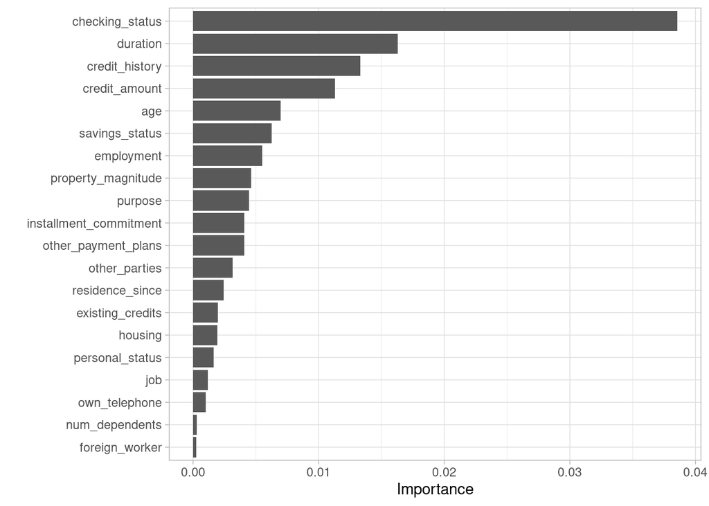

```r
ggplot(importance, aes(x = reorder(Feature, Importance), y = Importance)) +
  geom_col() + coord_flip() + xlab("")
```

# Prediction

- A model, once trained, can be used to predict outcomes from new data.
- We simulate new data by sampling from the credit data. No need to pay close attention what is going on here.

```r
# For each variable, we randomly sample 3 values with replacement
newdata = as.data.table(lapply(credit, sample, size = 3, replace = TRUE))
# we need to set the 'class' column to 'NA', otherwise mlr3 thinks this is the
# actual outcome. This is desirable for performance evaluation, but not here.
newdata$class = NULL
newdata
```

```
#>    checking_status duration credit_history             purpose credit_amount   savings_status employment
#> 1:        0<=X<200       24  existing paid             new car          1505       100<=X<500         <1
#> 2:     no checking       60  existing paid furniture/equipment          1940             <100        >=7
#> 3:        0<=X<200       10  existing paid furniture/equipment          2424 no known savings        >=7
#>    installment_commitment personal_status other_parties residence_since property_magnitude age other_payment_plans
#> 1:                      4     male single          none               1     life insurance  63                none
#> 2:                      1     male single          none               4  no known property  43                none
#> 3:                      2     male single          none               2  no known property  27                none
#>    housing existing_credits                       job num_dependents own_telephone foreign_worker
#> 1:     own                1 high qualif/self emp/mgmt              1           yes            yes
#> 2:    rent                2 high qualif/self emp/mgmt              1          none            yes
#> 3:     own                4                   skilled              1           yes            yes
```

## Predict Classes

- Let’s see what the models predict

```r
pred_logreg = learner_logreg$predict_newdata(newdata)
pred_rf = learner_rf$predict_newdata(newdata)

pred_logreg
```

```
#> <PredictionClassif> for 3 observations:
#>  row_id truth response
#>       1  <NA>     good
#>       2  <NA>     good
#>       3  <NA>     good
```

```r
pred_rf
```

```
#> <PredictionClassif> for 3 observations:
#>  row_id truth response
#>       1  <NA>     good
#>       2  <NA>     good
#>       3  <NA>     good
```

- The `predict()` function actually gives a `Prediction` object. It can be converted to a `data.table`, as well as inspected for other things.

```r
pred = learner_rf$predict_newdata(newdata)

head(as.data.table(pred))
```

```
#>    row_id truth response
#> 1:      1  <NA>     good
#> 2:      2  <NA>     good
#> 3:      3  <NA>     good
```

```r
pred$confusion
```

```
#>         truth
#> response good bad <NA>
#>     good    0   0    3
#>     bad     0   0    0
```

- The predictions may disagree, but which do we trust most? We should do Performance Evaluation and benchmarks!

## Predict Probabilities

- Learners may not only predict a class variable (“response”), but also their degree of “belief” / uncertainty in a given response.
- We achieve this by setting the `$predict_type` slot to `"prob"`.
- Sometimes this needs to be done *before* the learner is trained.
- Alternatively, we can directly create the learner with this option: `lrn("classif.log_reg", predict_type = "prob")`

```r
learner_logreg$predict_type = "prob"
```

```r
learner_logreg$predict_newdata(newdata)
```

```
#> <PredictionClassif> for 3 observations:
#>  row_id truth response prob.good  prob.bad
#>       1  <NA>     good 0.6507454 0.3492546
#>       2  <NA>     good 0.6823459 0.3176541
#>       3  <NA>     good 0.7818430 0.2181570
```

- Sometimes, you need to be careful when interpreting these values as probabilities!

# Performance Evaluation

To measure the performance of a learner on new unseen data, we usually mimic the scenario of unseen data by splitting up the data into training and test set. The training set is used for training the learner, and the test set is only used for predicting and evaluating the performance of the trained learner. Many resampling methods (cross-validation, bootstrap) repeat the splitting process in different ways.

- We need to specify the resampling scheme using the `rsmp()` function:

```r
resampling = rsmp("holdout", ratio = 2/3)
print(resampling)
```

```
#> <ResamplingHoldout> with 1 iterations
#> * Instantiated: FALSE
#> * Parameters: ratio=0.6667
```

- We use `resample()` to do the resampling calculation:

```r
res = resample(task, learner_logreg, resampling)
res
```

```
#> <ResampleResult> of 1 iterations
#> * Task: GermanCredit
#> * Learner: classif.log_reg
#> * Warnings: 0 in 0 iterations
#> * Errors: 0 in 0 iterations
```

- The default score of the measure is included in the `$aggregate()` slot:

```r
res$aggregate()
```

```
#> classif.ce
#>  0.2642643
```

- We can easily do differend resampling schemes, e.g. repeated holdout (`"subsampling"`), or cross validation. - Most methods do repeated train/predict cycles on different data subsets and aggregate the result (usually as the `mean()`). Doing this manually would require us to write loops.

```r
res_sub = resample(task, learner_logreg, rsmp("subsampling", repeats = 10))
res_sub$aggregate()
```

```
#> classif.ce
#>  0.2498498
```

```r
res_cv = resample(task, learner_logreg, rsmp("cv", folds = 10))
res_cv$aggregate()
```

```
#> classif.ce
#>      0.242
```

- We can also calculate scores for different measures (e.g., `msr("classif.fpr")` for the false positive rate).

```r
# false positive rate
res_cv$aggregate(msr("classif.fpr"))
```

```
#> classif.fpr
#>   0.5057089
```

```r
# false positive rate and false negative
msr_list = list(
  msr("classif.fpr"),
  msr("classif.fnr")
)
res_cv$aggregate(msr_list)
```

```
#> classif.fpr classif.fnr
#>   0.5057089   0.1310051
```

- There are a few more resampling methods, and quite a few more measures. List them in

```r
mlr_resamplings
```

```
#> <DictionaryResampling> with 6 stored values
#> Keys: bootstrap, custom, cv, holdout, repeated_cv, subsampling
```

```r
mlr_measures
```

```
#> <DictionaryMeasure> with 51 stored values
#> Keys: classif.acc, classif.auc, classif.bacc, classif.ce, classif.costs,
#>   classif.dor, classif.fbeta, classif.fdr, classif.fn, classif.fnr,
#>   classif.fomr, classif.fp, classif.fpr, classif.logloss, classif.mcc,
#>   classif.npv, classif.ppv, classif.precision, classif.recall,
#>   classif.sensitivity, classif.specificity, classif.tn, classif.tnr, classif.tp,
#>   classif.tpr, debug, oob_error, regr.bias, regr.ktau, regr.mae, regr.mape,
#>   regr.maxae, regr.medae, regr.medse, regr.mse, regr.msle, regr.pbias, regr.rae,
#>   regr.rmse, regr.rmsle, regr.rrse, regr.rse, regr.rsq, regr.sae, regr.smape,
#>   regr.srho, regr.sse, selected_features, time_both, time_predict, time_train
```

To get help on a resampling method, use `?mlr_resamplings_xxx`, for a measure do `?mlr_measures_xxx`. you can also use the [mlr3 reference](https://mlr3.mlr-org.com/reference/index.html) online.

Some measure, for example `"auc"`, require a “probability” prediction, instead of a response prediction, see **Probability Prediction**.

# Performance Comparison and Benchmarks

- We could compare `Learners` by evaluating `resample()` for each of them manually.
- `benchmark()` automatically performs resampling evaluations for multiple learners and tasks.
- Create fully crossed designs using `benchmark_grid()`: multiple `Learner`s **x** multiple `Task`s **x** multiple `Resampling`s

```r
lrn_list = list(
  lrn("classif.log_reg", predict_type = "prob"),
  lrn("classif.ranger", predict_type = "prob")
)

bm_design = benchmark_grid(task = task, resamplings = rsmp("cv", folds = 10), learners = lrn_list)
```

- Careful, large benchmarks may take a long time! This one should take less than a minute, however.
- In General, we want use *parallelization* to speed things up on multicore machines.
- This does **not work** on rstudio cloud, so only uncomment it locally!

```r
# future::plan("multiprocess")
```

```r
bmr = benchmark(bm_design)
```

- We can compare different measures. We compare misclassification rate and AUC.

```r
msr_list = list(msr("classif.ce"), msr("classif.auc"))
performances = bmr$aggregate(msr_list)
performances[, c("learner_id", "classif.ce", "classif.auc")]
```

```
#>         learner_id classif.ce classif.auc
#> 1: classif.log_reg      0.248   0.7802529
#> 2:  classif.ranger      0.232   0.8034423
```

# Outlook

- How did we do? We can check the [OpenML](https://www.openml.org/t/31) website for performances of other machine learning methods.
  - We see `ranger` is among the top methods
- Things we have not done that should be considered:
  - We have worked with default hyperparameters, but we may want to see if tuning them helps (Day 2)
  - Some preprocessing and feature extraction steps may sometimes be helpful (Day 3)

# Appendix

## R Pro Tips

- What are the arguments of `lrn()`, `tsk()`, etc. again? -> Think about the corresponding dictionary

```r
mlr_learners
```

```
#> <DictionaryLearner> with 21 stored values
#> Keys: classif.debug, classif.featureless, classif.glmnet, classif.kknn,
#>   classif.lda, classif.log_reg, classif.naive_bayes, classif.qda,
#>   classif.ranger, classif.rpart, classif.svm, classif.xgboost, regr.featureless,
#>   regr.glmnet, regr.kknn, regr.km, regr.lm, regr.ranger, regr.rpart, regr.svm,
#>   regr.xgboost
```

```r
mlr_tasks
```

```
#> <DictionaryTask> with 9 stored values
#> Keys: boston_housing, german_credit, iris, mtcars, pima, sonar, spam, wine, zoo
```

```r
mlr_measures
```

```
#> <DictionaryMeasure> with 51 stored values
#> Keys: classif.acc, classif.auc, classif.bacc, classif.ce, classif.costs,
#>   classif.dor, classif.fbeta, classif.fdr, classif.fn, classif.fnr,
#>   classif.fomr, classif.fp, classif.fpr, classif.logloss, classif.mcc,
#>   classif.npv, classif.ppv, classif.precision, classif.recall,
#>   classif.sensitivity, classif.specificity, classif.tn, classif.tnr, classif.tp,
#>   classif.tpr, debug, oob_error, regr.bias, regr.ktau, regr.mae, regr.mape,
#>   regr.maxae, regr.medae, regr.medse, regr.mse, regr.msle, regr.pbias, regr.rae,
#>   regr.rmse, regr.rmsle, regr.rrse, regr.rse, regr.rsq, regr.sae, regr.smape,
#>   regr.srho, regr.sse, selected_features, time_both, time_predict, time_train
```

```r
mlr_resamplings
```

```
#> <DictionaryResampling> with 6 stored values
#> Keys: bootstrap, custom, cv, holdout, repeated_cv, subsampling
```

- What are the arguments of a `$new()` constructor?

```r
formals(TaskClassif$public_methods$initialize)
```

[output not shown]

- What are the possible slots and functions of an object?

```r
# Writing `pred_rf$`, and pressing <TAB> should work.
# Otherwise:
names(pred_rf)
```

```
#>  [1] ".__enclos_env__" "missing"         "confusion"       "prob"
#>  [5] "response"        "truth"           "row_ids"         "predict_types"
#>  [9] "task_properties" "task_type"       "data"            "set_threshold"
#> [13] "help"            "initialize"      "clone"           "score"
#> [17] "print"           "format"
```

```r
# try names without `()` first
# and see if it is a function
```

- How do I see the help file of an object

```r
# The documentation is organized by object classes
class(pred_rf)
```

```
#> [1] "PredictionClassif" "Prediction"        "R6"
```

```r
# use ?PredictionClassif, ?Prediction etc.
# Try all elements listed in the class
```

## mlr3 and its Extensions

| Package | Functionality |
| --- | --- |
| `mlr3` | Framework for machine learning: `Task`, `Learner`, `resample()` and `benchmark()` |
| `mlr3learners` | Concrete `Learner`s for many popular machine learning implementations |
| `mlr3pipelines` | Dataflow programming of machine learning workflows. |
| `mlr3tuning` | Hyperparameter tuning for machine learning algorithms. |
| `mlr3filter` | Feature filtering |
| `mlr3viz` | Visualisations and plots |
| `paradox` | Auxiliary package providing (hyper)parameter handling |
| `mlr3misc` | Auxiliary functions |

## Packages

The non-`mlr3` packages we use:

| Package | Reason |
| --- | --- |
| `remotes` | We use this only to be able to do `remotes::install_github()`. This enables us to install packages from GitHub that are not on CRAN yet. |
| `data.table` | This provides a more efficient and versatile replacement for the `data.frame` datatype built into R. [Intro vignette](https://cran.r-project.org/web/packages/data.table/vignettes/datatable-intro.html) |
| `ggplot2` | A very powerful plotting tool. [Overview with link to “cheat sheets”](https://ggplot2.tidyverse.org/) |
| `callr` | Encapsulating function calls in external R sessions. [GitHub page](https://github.com/r-lib/callr#readme) |
| `future` | Parallelization to make use of multicore functionality. [GitHub page](https://github.com/HenrikBengtsson/future) |
| `skimr` | Plotting data summaries for exploratory data analysis. [Vignette](https://cran.r-project.org/web/packages/skimr/vignettes/Using_skimr.html) |
| `DataExplorer` | Plotting data for exploratory data analysis. [Vignette](https://cran.r-project.org/web/packages/DataExplorer/vignettes/dataexplorer-intro.html) |
| `rpart.plot` | Plotting CART trees. [Website](http://www.milbo.org/rpart-plot/) |
| `precrec` | Plotting AUC curves. [Vignette](https://cran.r-project.org/web/packages/precrec/vignettes/introduction.html) |
| `glmnet` | Provides the `"*.glmnet"` `Learner`s. Penalized regression is often surprisingly powerful, especially in high-dimensional settings. |
| `kknn` | Provides the `"*.kknn"` `Learner`s. k-nearest neighbor classification / regression is a classical machine learning technique. |
| `MASS` | Provides the `"*.lda"` and `"*.qda"` `Learner`s. |
| `ranger` | Provides the `"*.ranger"` `Learner`s. This is an implementation of the powerful “Random Forest” algorithm, which often works very well, even without parameter tuning. |
| `xgboost` | Provides the `"*.xgboost"` `Learner`s. Gradient boosting is often among the best performing machine learning methods, although it may require parameter tuning. |
| `e1071` | Provides the `"*.svm"` and `"classif.naive_bayes"` `Learner`s. SVMs (support vector machines) perform well, but are very dependent on correctly chosen kernel parameters. |